# HW2

Revina Polina

March 4, 2020

Загрузим библиотеки:

```r
library(haven)
library(dplyr)
library(ResourceSelection)
```

```
## ResourceSelection 0.3-5   2019-07-22
```

```r
library(caret)
library(ROCR)
library(InformationValue)
library(pscl)
library(broom)
library(memisc)
library(car)
```

Загрузим данные:

```r
data <- haven::read_dta("CDAhw2.dta", encoding = "latin1")
head(data)
```

```
## # A tibble: 6 x 409
##     qTO qNAS_P     qOBL   qRO  qINT  qANK VARIANT     qS1   qS2     qS3
##   <dbl>  <dbl> <dbl+lb> <dbl> <dbl> <dbl> <dbl+l> <dbl+l> <dbl> <dbl+l>
## 1     1   1010 88 [Ñ-Ï~    17    33     1   2 [2] 2 [æåí~    38 6 [ñðå~
## 2     1   1010 88 [Ñ-Ï~    17    33     2   1 [1] 1 [ìóæ~    21 8 [âûñ~
## 3     1   1010 88 [Ñ-Ï~    17    33     3   1 [1] 2 [æåí~    56 6 [ñðå~
## 4     1   1010 88 [Ñ-Ï~    17    33     4   2 [2] 1 [ìóæ~    45 6 [ñðå~
## 5     1   1010 88 [Ñ-Ï~    17    23     5   2 [2] 2 [æåí~    38 3 [ÏÒÓ~
## 6     1   1010 88 [Ñ-Ï~    17    23     6   2 [2] 1 [ìóæ~    72 6 [ñðå~
## # ... with 399 more variables: q1 <dbl+lbl>, q3_1 <dbl+lbl>,
## #   q3_2 <dbl+lbl>, q3_3 <dbl+lbl>, q3_4 <dbl+lbl>, q3_5 <dbl+lbl>,
## #   q3_6 <dbl+lbl>, q3_7 <dbl+lbl>, q3_8 <dbl+lbl>, q3_9 <dbl+lbl>,
## #   q3_10 <dbl+lbl>, q3_11 <dbl+lbl>, q3_12 <dbl+lbl>, q4A <dbl+lbl>,
## #   q4B <dbl+lbl>, q4C <dbl+lbl>, q4D <dbl+lbl>, q4E <dbl+lbl>,
## #   q5 <dbl+lbl>, q6 <dbl+lbl>, q7 <dbl+lbl>, q8_1 <dbl+lbl>,
## #   q8_2 <dbl+lbl>, q8_3 <dbl+lbl>, q8_4 <dbl+lbl>, q8_5 <dbl+lbl>,
## #   q8_6 <dbl+lbl>, q8_7 <dbl+lbl>, q8_8 <dbl+lbl>, q8_9 <dbl+lbl>,
## #   q8_10 <dbl+lbl>, q8_11 <dbl+lbl>, q8_12 <dbl+lbl>, q8_13 <dbl+lbl>,
## #   q8_14 <dbl+lbl>, q8_15 <dbl+lbl>, q8_16 <dbl+lbl>, q8_17 <dbl+lbl>,
## #   q8_18 <dbl+lbl>, q8_19 <dbl+lbl>, q8_20 <dbl+lbl>, q8_21 <dbl+lbl>,
## #   q8_22 <dbl+lbl>, q8_23 <dbl+lbl>, q8_24 <dbl+lbl>, q8_25 <dbl+lbl>,
## #   q8_26 <dbl+lbl>, q8_27 <dbl+lbl>, q8_28 <dbl+lbl>, q8_29 <dbl+lbl>,
## #   q8_30 <dbl+lbl>, q8_31 <dbl+lbl>, q8_32 <dbl+lbl>, q8_33 <dbl+lbl>,
## #   q8_34 <dbl+lbl>, q8_35 <dbl+lbl>, q8_36 <dbl+lbl>, q8_37 <dbl+lbl>,
## #   q8_38 <dbl+lbl>, q8_39 <dbl+lbl>, q8_40 <dbl+lbl>, q8_41 <dbl+lbl>,
## #   q8_42 <dbl+lbl>, q8_43 <dbl+lbl>, q8_44 <dbl+lbl>, q8_45 <dbl+lbl>,
## #   q8_46 <dbl+lbl>, q8_47 <dbl+lbl>, q8_48 <dbl+lbl>, q8_49 <dbl+lbl>,
## #   q9_1 <dbl+lbl>, q9_2 <dbl+lbl>, q9_3 <dbl+lbl>, q9_4 <dbl+lbl>,
## #   q9_5 <dbl+lbl>, q9_6 <dbl+lbl>, q9_7 <dbl+lbl>, q9_8 <dbl+lbl>,
## #   q9_9 <dbl+lbl>, q9_10 <dbl+lbl>, q9_11 <dbl+lbl>, q9_12 <dbl+lbl>,
## #   q9_13 <dbl+lbl>, q9_14 <dbl+lbl>, q9_15 <dbl+lbl>, q9_16 <dbl+lbl>,
## #   q9_17 <dbl+lbl>, q9_18 <dbl+lbl>, q9_19 <dbl+lbl>, q9_20 <dbl+lbl>,
## #   q9_21 <dbl+lbl>, q9_22 <dbl+lbl>, q9_23 <dbl+lbl>, q9_24 <dbl+lbl>,
## #   q9_25 <dbl+lbl>, q9_26 <dbl+lbl>, q9_27 <dbl+lbl>, q9_28 <dbl+lbl>,
## #   q9_29 <dbl+lbl>, q9_30 <dbl+lbl>, ...
```

**Целевая переменная**: Принимали ли вы участие в выборах в Государственную Думу России 4 декабря этого года? (q29)

Предикторы:

**Бинарная переменная**: пол респондента (s1)

**Непрерыная переменная**: возраст респондента (s2)

**Порядковая переменная**: “Как вы думаете, мы переживаем сейчас самые тяжелые времена, или они уже позади, или еще впереди?” (q5).

Оставим в массиве только необходимые переменные, удалим пропущенные значения:

```r
vote <- data %>% dplyr::select(qS1, qS2, q5, q29)
vote$q29[vote$q29 == 1] <- 1
vote$q29[vote$q29 == 2] <- 0

vote$q29 <- as.factor(vote$q29)
levels(vote$q29) <- c("0", "1")
table(vote$q29)
```

```
##
##    0    1
##  485 1112
```

```r
table(vote$qS1)
```

```
##
##   1   2
## 719 881
```

```r
vote$qS1 <- as.factor(vote$qS1)
table(vote$qS2)
```

```
##
## 18 19 20 21 22 23 24 25 26 27 28 29 30 31 32 33 34 35 36 37 38 39 40 41 42
## 30 25 27 32 31 44 44 50 45 34 27 19 30 25 16 25 19 22 39 26 25 30 44 27 36
## 43 44 45 46 47 48 49 50 51 52 53 54 55 56 57 58 59 60 61 62 63 64 65 66 67
## 26 28 31 20 34 24 37 25 33 33 34 47 32 47 33 27 26 29 15 19 14 21 18 11  4
## 68 69 70 71 72 73 74 75 76 77 78 79 80 81 82 83 84 85 88
## 10 11 16 11 21 19 12 13  9  7  5  3  4  8  2  5  2  1  1
```

```r
table(vote$q5)
```

```
##
##   1   2   3   9
## 348 440 574 238
```

```r
vote$q5[vote$q5 == 9] <- NA
vote$q5 <- as.factor(vote$q5)

vote <- na.omit(vote)

names(vote) <- c("gender", "age", "times", "target")

summary(vote)
```

```
##  gender       age        times   target
##  1:615   Min.   :18.00   1:348   0:394
##  2:744   1st Qu.:29.00   2:439   1:965
##          Median :44.00   3:572
##          Mean   :44.19
##          3rd Qu.:56.00
##          Max.   :88.00
```

Оценим логит-модель:

```r
logit <- glm(target ~ gender + age + times, data = vote, family = binomial(link = "logit"), x = TRUE)
summary(logit)
```

```
##
## Call:
## glm(formula = target ~ gender + age + times, family = binomial(link = "logit"),
##     data = vote, x = TRUE)
##
## Deviance Residuals:
##     Min       1Q   Median       3Q      Max
## -2.2111  -1.2732   0.6903   0.8497   1.2255
##
## Coefficients:
##              Estimate Std. Error z value Pr(>|z|)
## (Intercept) -0.595657   0.208956  -2.851  0.00436 **
## gender2      0.337323   0.123077   2.741  0.00613 **
## age          0.027899   0.003995   6.983 2.89e-12 ***
## times2       0.435992   0.164728   2.647  0.00813 **
## times3      -0.018906   0.150194  -0.126  0.89983
## ---
## Signif. codes:  0 '***' 0.001 '**' 0.01 '*' 0.05 '.' 0.1 ' ' 1
##
## (Dispersion parameter for binomial family taken to be 1)
##
##     Null deviance: 1636.5  on 1358  degrees of freedom
## Residual deviance: 1564.4  on 1354  degrees of freedom
## AIC: 1574.4
##
## Number of Fisher Scoring iterations: 4
```

1. Проверим гипотезу о согласии наблюдаемх значений и модели посредством Hosmer-Lemeshow goodness-of-fit test.

H0: нет различий между предсказанными значениями вероятности и наблюдаемыми значениями в отдельных ранжированных подгруппах.

Для данного теста выполняется следующее:

1. Вычисляется $P(success)$ для каждого наблюдения, далее это значение ранжируется от наименьшего к наибольшему.
2. Выборка разбивается на N-ное количество подгрупп: в качестве N берется 10 или N > k+1, где k – количество предикторов.
3. По каждой подгруппе вычисляется статистика, она представляет собой разницу между наблюдаемыми и предсказанными значениями:

$\sum_{j=1}^{k}\sum_{i=1}^{N}\frac{(Observed_{i}-Expected_{i})^2}{Expected_{i}}$

```r
hl <- hoslem.test(logit$y, fitted(logit), g=10)
hl.groups <- data.frame(cbind(hl$observed,hl$expected))
hl.groups <- mutate(hl.groups, total = y0 + y1)
hl.groups
```

```
##    y0  y1    yhat0     yhat1 total
## 1  66  71 65.35519  71.64481   137
## 2  61  79 56.91831  83.08169   140
## 3  49  82 48.12242  82.87758   131
## 4  42  96 45.03977  92.96023   138
## 5  45  90 39.87566  95.12434   135
## 6  36  98 36.25473  97.74527   134
## 7  27 118 34.38997 110.61003   145
## 8  19 110 27.02315 101.97685   129
## 9  23 114 23.95464 113.04536   137
## 10 26 107 17.06615 115.93385   133
```

```r
hl
```

```
##
##  Hosmer and Lemeshow goodness of fit (GOF) test
##
## data:  logit$y, fitted(logit)
## X-squared = 12.279, df = 8, p-value = 0.1392
```

Мы наблюдаем значением p-value>0.05, следовательно, нет оснований для отвержения H0 об отсутствии различий между предсказанными и наблюдаемыми значениями.

2. Рассчитаем значение baseline accuracy.

```r
data.frame(table(vote$target))
```

```
##   Var1 Freq
## 1    0  394
## 2    1  965
```

```r
max(data.frame(table(vote$target))[,2])/sum(data.frame(table(vote$target))[,2])
```

```
## [1] 0.7100809
```

3. Сохраним предсказанные вероятности в отдельную переменную, определим значение threshold как 0.5: вероятности < 0.5 определяются в группу 0.

```r
pred1 <- ifelse(predict(logit, type = "response") < 0.5, 0, 1)
pred1 <- as.factor(pred1)
vote$targets <- as.factor(vote$target)
levels(pred1)
```

```
## [1] "0" "1"
```

```r
levels(vote$targets)
```

```
## [1] "0" "1"
```

```r
caret::confusionMatrix(pred1, as.factor(vote$target), positive= "1")
```

```
## Confusion Matrix and Statistics
##
##           Reference
## Prediction   0   1
##          0  16  19
##          1 378 946
##
##                Accuracy : 0.7079
##                  95% CI : (0.6829, 0.7319)
##     No Information Rate : 0.7101
##     P-Value [Acc > NIR] : 0.5844
##
##                   Kappa : 0.0286
##
##  Mcnemar's Test P-Value : <2e-16
##
##             Sensitivity : 0.98031
##             Specificity : 0.04061
##          Pos Pred Value : 0.71450
##          Neg Pred Value : 0.45714
##              Prevalence : 0.71008
##          Detection Rate : 0.69610
##    Detection Prevalence : 0.97425
##       Balanced Accuracy : 0.51046
##
##        'Positive' Class : 1
##
```

Согласно confusion matrix определим следующее:

```r
TP <- 946

FP <- 378

FN <- 19

TN <- 16
```

$H_{0}$: наблюдение относится к группе неголосовавших.

Ошибка первого рода:

$error_{1} = P(reject|H_{0}) = \frac{FP}{FP+TN}$

```r
# er1 = 1 - 0.04061
er1 <- FP/(FP+TN)
er1
```

```
## [1] 0.9593909
```

Следовательно, вероятность отнесения человека к группе голосовавших в то время, как он принадлежит к группе неголосовавших, то есть вероятность “ложноположительного срабатывания” равна 0.96.

Ошибка второго рода:

$error_{2} = P(NOTreject|H1) = \frac{FN}{FN+TP}$

```r
# 1 - 0.98031
er2 <- FN/(FN+TP)
er2
```

```
## [1] 0.01968912
```

Следовательно, вероятность отнесения человека к группе неголосовавших в то время, как он принадлежит к группе голосовавших, то есть вероятность “ложноотрицательного срабатывания” равна 0.02.

Мощность:

$Power = P(reject|H1) = 1 - \frac{FN}{FN+TP}$

```r
power <- 1 - er2
power
```

```
## [1] 0.9803109
```

Следовательно, вероятность отнесения человека к группе голосовавших при том, что человек относится к группе голосовавших 0.98.

Accuracy алгоритма (0.7079) не отличается baseline accuracy (0.71).

4. Сравним данное решение с алгоритмом с **оптимальным порогом, выбранным на основе минимизации ошибки классификации**.

```r
pred <- predict(logit, vote, type='response')
cutoff <- optimalCutoff(vote$target, pred)
cutoff
```

```
## [1] 0.4756143
```

```r
misClassError(vote$target, pred, threshold = cutoff)
```

```
## [1] 0.2899
```

```r
pred2 <- ifelse(predict(logit, type = "response") < cutoff, 0, 1)
pred2 <- as.factor(pred2)
caret::confusionMatrix(pred2, vote$target, positive = "1")
```

```
## Confusion Matrix and Statistics
##
##           Reference
## Prediction   0   1
##          0   2   2
##          1 392 963
##
##                Accuracy : 0.7101
##                  95% CI : (0.6852, 0.7341)
##     No Information Rate : 0.7101
##     P-Value [Acc > NIR] : 0.5136
##
##                   Kappa : 0.0042
##
##  Mcnemar's Test P-Value : <2e-16
##
##             Sensitivity : 0.997927
##             Specificity : 0.005076
##          Pos Pred Value : 0.710701
##          Neg Pred Value : 0.500000
##              Prevalence : 0.710081
##          Detection Rate : 0.708609
##    Detection Prevalence : 0.997057
##       Balanced Accuracy : 0.501502
##
##        'Positive' Class : 1
##
```

**Accuracy**: доля всех верно классифиццированных наблюдений: 0.7101, что не отличается от модели с выбранным вручную порогом отсечения.

**Специфичность (TNR)**: доля наблюдений, правильно классифицированных как непроголосовавших от общего количества непроголосоваших равна 0.005.

**Чувствительность (TPR)**: доля наблюдений, правильно классифицированных как проголосовавших от общего количества проголосовавших равна 0.998.

**Precision**: доля наблюдений, правильно отнесенных к группе голосовавих от общего количества наблюдений, классифицированных как проголосовавших, равна 0.71.

Сравним данное решение с алгоритмом с **оптимальным порогом, выбранным в соответствии с Youden index**.

```r
cutoff <- optimalCutoff(vote$target, pred, optimiseFor = "Both")
cutoff
```

```
## [1] 0.7256143
```

```r
pred5 <- ifelse(predict(logit, type = "response") < cutoff, 0, 1)
pred5 <- as.factor(pred5)
caret::confusionMatrix(pred5, vote$target, positive = "1")
```

```
## Confusion Matrix and Statistics
##
##           Reference
## Prediction   0   1
##          0 283 447
##          1 111 518
##
##                Accuracy : 0.5894
##                  95% CI : (0.5627, 0.6157)
##     No Information Rate : 0.7101
##     P-Value [Acc > NIR] : 1
##
##                   Kappa : 0.2037
##
##  Mcnemar's Test P-Value : <2e-16
##
##             Sensitivity : 0.5368
##             Specificity : 0.7183
##          Pos Pred Value : 0.8235
##          Neg Pred Value : 0.3877
##              Prevalence : 0.7101
##          Detection Rate : 0.3812
##    Detection Prevalence : 0.4628
##       Balanced Accuracy : 0.6275
##
##        'Positive' Class : 1
##
```

**Accuracy**, то есть доля правильны ответов: 0.5894, что значительно ниже значений предыдущих моделей.

**Специфичность (TNR)**: 0.7183 Следовательно, доля наблюдений, правильно классифицированных как непроголосовавших от общего количества непроголосоваших равна 0.7183.

**Чувствительность (TPR)**: 0.5368. Следовательно, доля наблюдений, правильно классифицированных как проголосовавших от общего количества проголосовавших равна 0.5368.

**Precision**: 0.8235. Следовательно, доля наблюдений, правильно отнесенных к группе голосовавих от общего количества наблюдений, определенных к группе голосовавших равна 0.8235.

Сравнение:

Baseline accuracy и accuracy модели с оптимальным порогом, выбранным на основе минимизации ошибки классифицкации, не различается, при этом accuracy модели с оптимальным порогом, выбранным на основе Youden index значительно ниже. У последней модели также ниже чувствительность и выше специфичность. Чувствительность и специфичность первых двух моделей не различается. Precision у последней модели значительно выше, значение данной метрики не отличается у первых двух моделей. В данном примере предпочтем модель с наибольшей чувствительность, так как нам важнее правильно предсказывать прешедших на выборы. Следовательно, выберем вторую модель.

5. Проверка массива.

Outliers

```r
car::outlierTest(logit) # studentized residuals
```

```
## No Studentized residuals with Bonferroni p < 0.05
## Largest |rstudent|:
##     rstudent unadjusted p-value Bonferroni p
## 394 -2.21869           0.026508           NA
```

Следовательно, в массиве нет outlier’ов, то есть наблюдений имеющих нетипичные значения по Y.

Визуализируем: построим diagnostic plots.

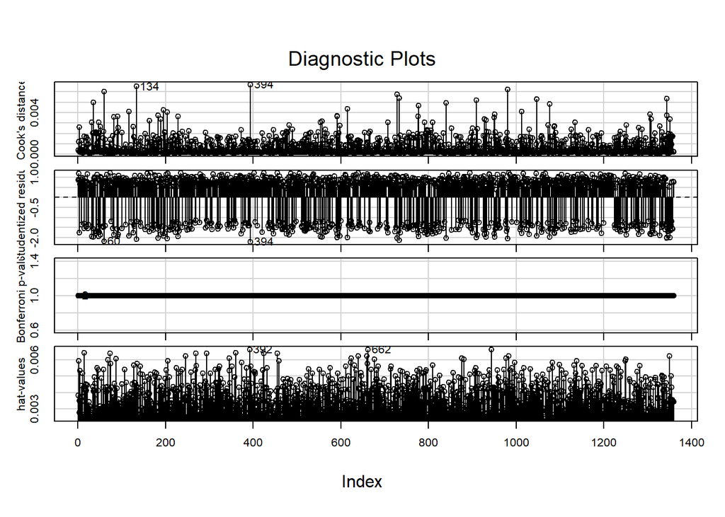

```r
car::influenceIndexPlot(logit)
```

Согласно графику, levarages, т.е. наблюдения, имеющие нетипичные значения по X, и outliers отсутствуют.

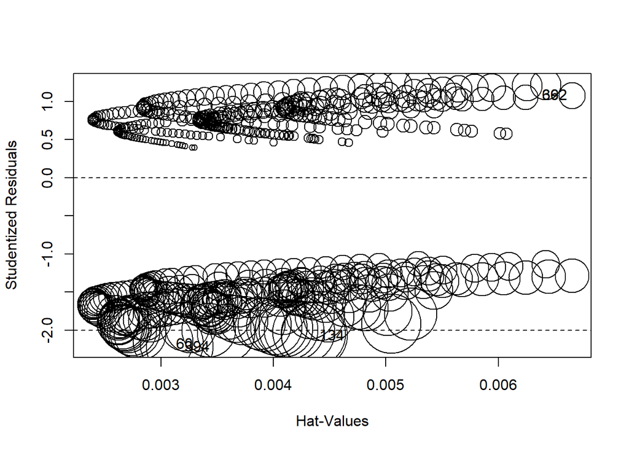

```
##       StudRes         Hat       CookD
## 60  -2.183319 0.003096231 0.006031832
## 134 -2.070984 0.004368355 0.006522181
## 392  1.078203 0.006654410 0.001056903
## 394 -2.218690 0.003169376 0.006714334
## 662  1.078203 0.006654410 0.001056903
```

```r
car::influencePlot(logit)
```

Infuential observations присутствуют.

Переоценим модель на массиве без этих наблюдений.

```r
influence_data <- augment(logit) %>% mutate(index = 1:n())
top_cook <- influence_data %>% top_n(5, .cooksd)
top_cook$index
```

```
## [1]  60 134 394 728 981
```

```r
m1_logit_upd <- update(logit, subset = c(-top_cook$index))
mtable(logit, m1_logit_upd)
```

```
##
## Calls:
## logit: glm(formula = target ~ gender + age + times, family = binomial(link = "logit"),
##     data = vote, x = TRUE)
## m1_logit_upd: glm(formula = target ~ gender + age + times, family = binomial(link = "logit"),
##     data = vote, subset = c(-top_cook$index), x = TRUE)
##
## =============================================
##                      logit     m1_logit_upd
## ---------------------------------------------
##   (Intercept)       -0.596**     -0.697***
##                     (0.209)      (0.211)
##   gender: 2/1        0.337**      0.339**
##                     (0.123)      (0.124)
##   age                0.028***     0.031***
##                     (0.004)      (0.004)
##   times: 2/1         0.436**      0.478**
##                     (0.165)      (0.167)
##   times: 3/1        -0.019       -0.035
##                     (0.150)      (0.151)
## ---------------------------------------------
##   Log-likelihood  -782.214     -770.818
##   N               1359         1354
## =============================================
##   Significance: *** = p < 0.001;
##                 ** = p < 0.01; * = p < 0.05
```

Привело ли это к изменениям в оценках коэффициентов? Можно ли оставить эти наблюдения в массиве?

6. Предикторы новых моделей:

**ec**: экономическая политика правительства;

**new**: изменения в стране к лучшему.

```r
new_vote <- data %>% dplyr::select(qS1, qS2, q5, q6, q7, q29)
new_vote$q29 <- as.factor(new_vote$q29)
levels(new_vote$q29) <- c("0", "1")
table(new_vote$q29)
```

```
##
##    0    1
## 1112  485
```

```r
table(new_vote$qS1)
```

```
##
##   1   2
## 719 881
```

```r
new_vote$qS1 <- as.factor(new_vote$qS1)
new_vote$q5[new_vote$q5 == 9] <- NA
new_vote$q5 <- as.factor(new_vote$q5)
names(new_vote) <- c("gender", "age", "times", "ec", "new", "target")

new_vote$ec[new_vote$ec == 9] <- NA
new_vote$new[new_vote$new == 9] <- NA

new_vote$ec <- as.factor(new_vote$ec)
new_vote$new <- as.factor(new_vote$new)

new_vote <- na.omit(new_vote)
summary(new_vote)
```

```
##  gender       age        times   ec      new     target
##  1:567   Min.   :18.00   1:317   1:112   1: 46   0:894
##  2:683   1st Qu.:29.00   2:408   2:674   2:285   1:356
##          Median :43.50   3:525   3:464   3:472
##          Mean   :44.04                   4:297
##          3rd Qu.:56.00                   5:150
##          Max.   :88.00
```

```r
logit <-  glm(target ~ gender + age + times, data = new_vote, family = binomial(link = "logit"))
logit2 <- glm(target ~ gender + age + ec, data = new_vote, family = binomial(link = "logit"))
logit3 <- glm(target ~ gender + age + new, data = new_vote, family = binomial(link = "logit"))

AIC(logit, logit2)
```

```
##        df      AIC
## logit   5 1444.251
## logit2  5 1444.100
```

```r
BIC(logit, logit2)
```

```
##        df      BIC
## logit   5 1469.905
## logit2  5 1469.755
```

```r
AIC(logit, logit3)
```

```
##        df      AIC
## logit   5 1444.251
## logit3  7 1439.225
```

```r
BIC(logit, logit3)
```

```
##        df      BIC
## logit   5 1469.905
## logit3  7 1475.141
```